# SMCB Project 1

February 24, 2023

# Problem 1: Conditional independence and BNs

## (a)

$A \perp B | C$ holds, but $A \perp B$ does not hold.

### Proof for $A \perp B | C$

From the BN, we know that

$$P(A,B,C) = P(A|C) P(B|C) P(C)$$

To prove that $A \perp B | C$, we need to show that $P(A, B|C) = P(A|C)P(B|C)$.

$$\begin{aligned}
P(A,B|C) &= \frac{P(A, B, C)}{P(C)} \\
&= \frac{P(A|C)P(B|C)P(C)}{P(C)} \\
&= P(A|C)P(B|C)
\end{aligned}$$

### Disproof for $A \perp B$

Consider $P(A, B) = \sum_{C} P(A, B, C)$. From the BN, we have:

$$\begin{aligned}
P(A, B) &= \sum_{C} P(A,B,C) \\
&= \sum_{C} P(A|C)P(B|C)P(C) \\
&= \sum_{C}
\frac{P(C|A)P(A)}{P(C)}\frac{P(C|B)P(B)}{P(C)}P(C) \\
&= P(A)P(B) \sum_{C} \frac{P(C|A)P(C|B)}{P(C)} \\
&\neq P(A)P(B) & \text{(usually)}
\end{aligned}$$

Hence, in general $A \perp B$ does not hold for this Bayesian network.

## (b)

$A \perp B | C$ does not hold, but $A \perp B$ holds

### Proof for $A \perp B$

From the BN, we know that

$$P(A,B,C) = P(A)P(B)P(C|A,B)$$

We know from Bayes theorem that $P(A, B, C) = P(C|A,B)P(A,B)$.

Hence we have:

$$P(C|A,B)P(A)P(B) = P(C|A,B)P(A,B)$$

i.e., $P(A, B) = P(A)P(B)$. We have consequently proven that $A \perp B$.

# Problem 2: Markov blanket

The Markov blanket $MB(D)$ is $\{B, C, E, F, G\}$, where $B$ and $F$ are the parents of $D$, $C$ and $G$ are the children of $D$, and $E$ is the co-parent of $D$.

To prove that the conditional probability of $P(X_k|X_{n\neq k})$ is equivalent to $P(X_k|MB(X_k))$, we can prove that $\forall X_{j}$ where $j \in [1, n], j\neq k$, if $X_j \notin MB(X_k)$, then $X_j \perp X_k | MB(X_k)$.

For this specific question, we need to prove that $A \perp D | MB(D)$. It is obvious that $A \perp D | MB(D)$ because $A$ and $D$ are d-separated given $MB(D)$ since $E \in MB(D)$ is on the (only) path from $A$ to $D$ and $E$ is in a cascade structure $A \rightarrow E \rightarrow G$.

# Problem 3

## Package and Dataset Preparation

```r
list.of.packages <- c("GGally", "BiDAG", "igraph")
new.packages <- list.of.packages[!(list.of.packages %in% installed.packages()[,"Package"])]
if(length(new.packages)) install.packages(new.packages)
```

```r
library(GGally)
```

```r
library(BiDAG)
library(igraph)
set.seed(2023)
```

```r
# download da
df <- read.csv(file="https://raw.githubusercontent.com/felixleopoldo/benchpress/master/resources/data/mydatasets/2005_sachs_2_cd3cd28icam2_log_std.csv")
head(df)
```

|  | Akt | Erk | Jnk | Mek | P38 | PIP2 | PIP3 | PKA | PKC | Plcg | Raf |
| --- | --- | --- | --- | --- | --- | --- | --- | --- | --- | --- | --- |
| 1 | -0.63433612 | -0.1117883 | -0.3707515 | -0.58558428 | -0.06458972 | 0.6818205 | -0.32402294 | -0.04326735 | -0.6878319 | -0.3955337 | -0.5148379 |
| 2 | -3.04091029 | -2.5379116 | 1.0548648 | -0.08291055 | -0.10231212 | 1.6658269 | 1.18130472 | -4.07209170 | 0.2993658 | 0.6777917 | -0.1101130 |
| 3 | -0.10795269 | -0.7494918 | 0.7096003 | 0.86363654 | -0.23355736 | -1.1057101 | 0.09555701 | -0.43897960 | -0.1565200 | -0.2206535 | 0.6457071 |
| 4 | -0.05846518 | 0.3253933 | 1.1038411 | -1.69765652 | -0.18079485 | 1.3026594 | 1.36106920 | -0.12200029 | 0.1600811 | 0.9960279 | -1.6614249 |
| 5 | 0.32095996 | 0.5678002 | 0.6809554 | -0.22157981 | -0.11327037 | 0.1823161 | -0.08623616 | -0.74481674 | -0.2974304 | -0.7794014 | -0.3258126 |
| 6 | -0.25409240 | -0.2603138 | -1.6322745 | -1.61663169 | 0.92638128 | -1.3078990 | 0.23050612 | -0.11188567 | -0.6522629 | -0.9392948 | -0.8496813 |

## (a)

Number of variables ($n$): $11$ Number of observations ($N$): $902$

```r
str(df)
```

```
## 'data.frame':    902 obs. of  11 variables:
##  $ Akt : num  -0.6343 -3.0409 -0.108 -0.0585 0.321 ...
##  $ Erk : num  -0.112 -2.538 -0.749 0.325 0.568 ...
##  $ Jnk : num  -0.371 1.055 0.71 1.104 0.681 ...
##  $ Mek : num  -0.5856 -0.0829 0.8636 -1.6977 -0.2216 ...
##  $ P38 : num  -0.0646 -0.1023 -0.2336 -0.1808 -0.1133 ...
##  $ PIP2: num  0.682 1.666 -1.106 1.303 0.182 ...
##  $ PIP3: num  -0.324 1.1813 0.0956 1.3611 -0.0862 ...
##  $ PKA : num  -0.0433 -4.0721 -0.439 -0.122 -0.7448 ...
##  $ PKC : num  -0.688 0.299 -0.157 0.16 -0.297 ...
##  $ Plcg: num  -0.396 0.678 -0.221 0.996 -0.779 ...
##  $ Raf : num  -0.515 -0.11 0.646 -1.661 -0.326 ...
```

Visualization of the transformed data using `ggpairs` function.

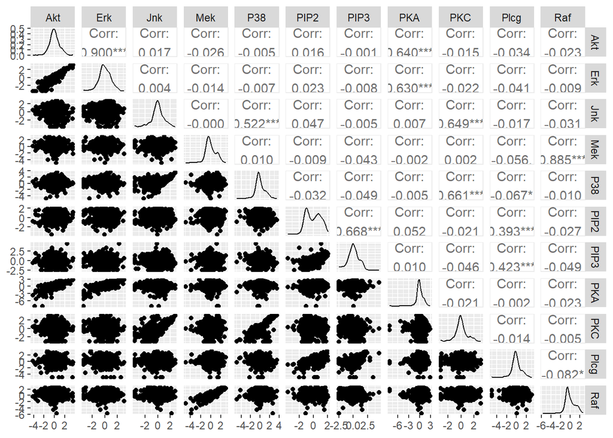

```r
ggpairs(df)
```

Randomly split the data into 80% traning data and 20% test data.

```r
train_data_size <- floor(0.8*nrow(df))
picked <- sample(seq_len(nrow(df)), size=train_data_size)
train_data <- df[picked, ]
test_data  <- df[-picked,]
```

Initialize the parameters using the function `BiDAG::scoreparameters` with the training data and the Bayesian Gaussian equivalent (BGe) score.

```r
train_scorepar <- BiDAG::scoreparameters(scoretype="bge", train_data)
test_scorepar <- BiDAG::scoreparameters(scoretype="bge", test_data)
```

## (b)

Learn a Bayesian network using the `BiDAG::iterativeMCMC` function.

```r
BN <- BiDAG::iterativeMCMC(scorepar=train_scorepar)
```

```
## maximum parent set size is 2
## core space defined, score table are being computed
## score tables completed, iterative MCMC is running
```

Plot the DAG.

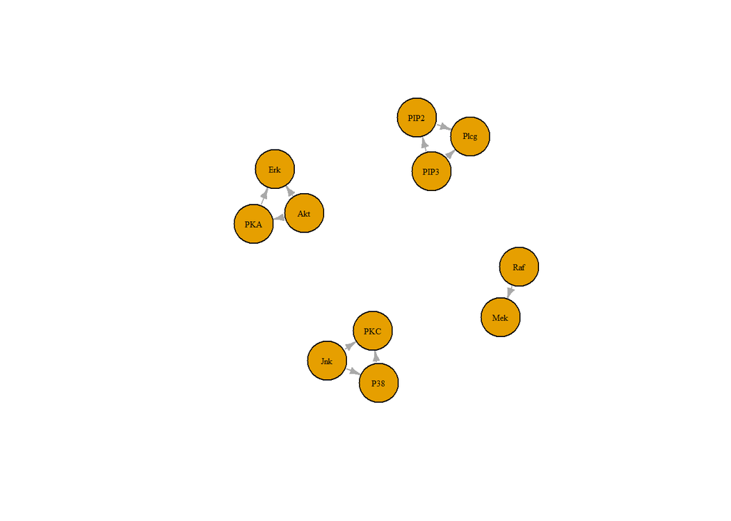

```r
DAG <- BiDAG::getDAG(BN)
g <- igraph::graph.adjacency(DAG, mode="directed")
test.layout <- layout_nicely(g)
igraph::plot.igraph(g,
                    edge.arrow.size=.5,
                    vertex.size=30,
                    vertex.label.cex=.5,
                    vertex.label.color="black",
                    layout=test.layout
)
```

Evaluate the log score of the test data agaisnt the estimated DAG using `BiDAG::scoreagainstDAG`.

```r
log_score <- BiDAG::scoreagainstDAG(scorepar=test_scorepar, incidence=DAG)
mean(log_score)
```

```
## [1] -12.42144
```

## (c)

```r
res <- data.frame(matrix(ncol=5, nrow=2))
colnames(res) <- c(1, 2, 3, 4, 5)
rownames(res) <- c("ecount", "logscore")
```

```r
procedure <- function(am, index=1) {
    picked <- sample(seq_len(nrow(df)), size=train_data_size)
    train_data <- df[picked, ]
    test_data  <- df[-picked,]
    train_scorepar <- BiDAG::scoreparameters(
        scoretype="bge",
        train_data,
        bgepar=list(am=am, aw=NULL)
    )
    BN <- BiDAG::iterativeMCMC(scorepar=train_scorepar)
    return(BN)
}
```

```r
list.of.packages <- c("foreach", "doParallel", "doRNG")
new.packages <- list.of.packages[!(list.of.packages %in% installed.packages()[,"Package"])]
if(length(new.packages)) install.packages(new.packages)
```

```r
library(foreach)
library(doParallel)
library(doRNG)
library(parallel)
```

```r
num_cores <- detectCores()
registerDoParallel(num_cores)
index <- 1
# foreach (am=c(1e-3, 1e-1, 1e0, 1e1, 1e2)) %do% {
#     v <- foreach (i=1:100, .combine=rbind) %dorng% {
#         picked <- sample(seq_len(nrow(df)), size=train_data_size)
#         train_data <- df[picked, ]
#         test_data  <- df[-picked,]
#         train_scorepar <- BiDAG::scoreparameters(
#             scoretype="bge", train_data,
#             bgepar=list(am=am, aw=NULL)
#         )
#         test_scorepar <- BiDAG::scoreparameters(
#             scoretype="bge", test_data,
#             bgepar=list(am=am, aw=NULL)
#         )
#         BN <- BiDAG::iterativeMCMC(scorepar=train_scorepar)
#         DAG <- BiDAG::getDAG(BN)
#         g <- igraph::graph.adjacency(DAG, mode="directed")
#         ecount <- igraph::ecount(g)
#         log_score <- BiDAG::scoreagainstDAG(
#             scorepar=test_scorepar,
#             incidence=DAG
#         )
#         avg_log_score <- mean(log_score)
#         return(c(ecount=ecount, log_score=avg_log_score))
#     }
#     avg <- colMeans(v)
#     res[1, index] <- avg[1]
#     res[2, index] <- avg[2]
#     index <- index + 1
# }
stopImplicitCluster()
print(res)
```

```
##           1  2  3  4  5
## ecount   NA NA NA NA NA
## logscore NA NA NA NA NA
```

```r
scorepar <- BiDAG::scoreparameters(scoretype="bge", df, bgepar=list(am=1e-1, aw=NULL))
BN <- BiDAG::iterativeMCMC(scorepar=scorepar)
```

```
## maximum parent set size is 3
## core space defined, score table are being computed
## score tables completed, iterative MCMC is running
```

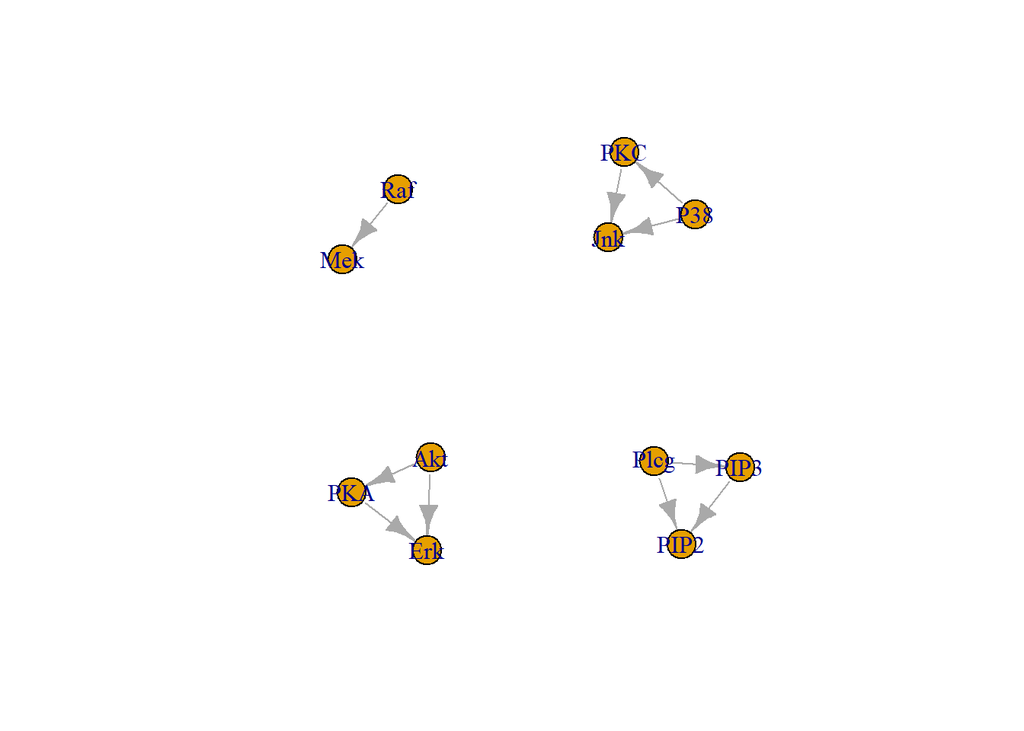

```r
DAG <- BiDAG::getDAG(BN)
g <- igraph::graph.adjacency(DAG, mode="directed")
igraph::plot.igraph(g)
```